# COVID-19 Symptom Surveys through Google

Ryan Tibshirani

2020-09-07

Since April 2020, in addition to our massive daily survey advertised on Facebook, we’ve been running (even-more-massive) surveys through Google to track the spread of COVID-19 in the United States. At its peak, our Google survey was taken by over 1.2 million people in a single day, and over its first month in operation, averaged over 600,000 daily respondents. In mid-May, we paused daily dissemination of this survey in order to focus on our (longer, more complex) survey through Facebook, but we plan to bring back the Google survey this fall. This blog post covers some key differences between our Google and Facebook surveys, explains the backstory behind the “CLI-in-community” question as it arose through our collaboration with Google, and shares some of our thinking about next steps for the Google survey. We also give a forecasting demo that shows how both the Google and Facebook survey data can be used to improve accuracy in short-term (1-2 weeks ahead) county-level COVID-19 case forecasts.

Since April 2020, in addition to our [massive daily survey advertised on Facebook](https://delphi.cmu.edu/blog/2020/08/26/covid-19-symptom-surveys-through-facebook/), we’ve been running (even-more-massive) surveys through Google to track the spread of COVID-19 in the United States. At its peak, our Google survey was taken by over 1.2 million people in a single day, and over its first month in operation, averaged about 600,000 daily respondents. As usual, we make aggregated data from this survey available through our [COVIDcast API](https://cmu-delphi.github.io/delphi-epidata/api/covidcast.html).

In mid-May, we decided to pause daily dissemination of this survey in order to focus on our (longer, more complex) survey through Facebook, but we plan to bring back the Google survey this fall. The two surveys are, in fact, quite different and complement each other nicely. This blog post covers some key differences between our Google and Facebook surveys, explains the backstory behind the “CLI-in-community” question as it arose through our collaboration with Google’s team, and shares some of our thinking about next steps for the Google survey. We also give a forecasting demo that shows how both the Google and Facebook survey data can be used to improve accuracy in short-term (1-2 weeks ahead) county-level COVID-19 case forecasts.

## Short Background

Back in March 2020, around the time we began discussions with Facebook about COVID-19 symptom surveys, we pitched the same idea to Google. Our motivation, [as we explained in our last post](https://delphi.cmu.edu/blog/2020/08/26/covid-19-symptom-surveys-through-facebook/#why-run-these-surveys), has been to produce real-time, county-level data streams of self-reported COVID symptoms that can potentially serve as **early indicators** of COVID activity in the US. As we noted in that post, we weren’t the only data scientists who thought of running COVID-19 symptom surveys, and several other groups had deployed surveys before us. What distinguished our strategy from others’ was the pursuit of a giant like Google to achieve widespread and continuous dissemination (well beyond what we could do ourselves). Google’s willingness to help was a *huge* win for us. Of all the partnerships we formed to create new COVID-19 indicators, our deal with Google was the first to come through. This gave us an invaluable confidence boost, and taught us the silver lining of this pandemic: that many people are truly generous and willing to help. Google’s contributions didn’t stop there—they have been helping us in [various ways ever since](https://blog.google/outreach-initiatives/google-org/google-supports-covid-19-ai-and-data-analytics-projects).

Our initial survey with Google launched in late March, deployed through various websites and apps (with whom Google partners to run questionnaires). Each respondent opted-in to answering the survey and agreed to legal disclosures about how the data would be used. The survey asked just a single question:

> Do you or anyone in your household have a fever of at least 100 °F, along with cough, shortness of breath, or difficulty breathing?

This pattern of symptoms defines a condition called **COVID-like illness** or **CLI**. A respondent could reply “Yes”, “No”, or “Prefer not to say”. We’re also given the respondent’s (inferred) county from IP address lookup. At the start, this survey data allowed us to estimate the daily % CLI, the percentage of people with COVID-like illness, in over 1,000 counties across the US. After about 2 weeks, we stopped the survey. Google wondered whether we could get equally useful information without asking a question of such a sensitive nature. In general, asking a person about their health (or their family’s health) is not common practice on Google’s survey platform. The hope was that asking a broader question might also improve response rates, reduce costs, and increase the number of potential respondents.

## CLI-in-Community

Working with Brett Slatkin (engineering lead of Google Surveys) and Hal Varian (Google’s chief economist), we looked for a new question. Brett came up with a list of questions that were acceptable, and the most promising among them was:

> Do you know of someone in your community who is sick with a fever, along with cough, shortness of breath, or difficulty breathing right now?

We decided to deploy this proxy question[^1] on April 11, 2020. We narrowed our focus to fewer counties: roughly the top 600 in terms of population, and estimated the daily % CLI-in-community, the percentage of people who *know someone in their community* with COVID-like illness. The initial results far exceeded our expectations, and were promising enough that within days we added this CLI-in-community question to our survey through Facebook.

To give you a feel for the data, below we plot the daily new COVID-19 cases per 100,000 people versus the estimated % CLI-in-community from our Google survey, at the state level, averaged over April 11 to mid-May. This is shown on the left, and on the right, we reproduce this with the estimated % CLI-in-community from our Facebook survey. In both plots, we see a reassuring trend, but the trend on the left is noticeably stronger. Indeed, the correlation here between the Google signal and case rates is 0.84, while that between the Facebook signal and case rates is 0.64. To be fair, we should note that the Google signal comprises a much larger number of survey respondents (as we’ll emphasize next), and the Facebook signal’s correlations to case rates shot up in mid-June (as we saw last time and we’ll revisit, shortly).

[figure not shown]

```r
library(covidcast)
library(dplyr)
library(ggplot2)
library(gridExtra)

# Fetch state-level Google % CLI-in-community signal
df_go = covidcast_signal("google-survey", "smoothed_cli", geo_type = "state")

# Fetch state-level Facebook % CLI-in-community signal and JHU confirmed case
# incidence proportion, restricted to the Google signal's time range
start_day = min(df_go$time_value)
end_day = max(df_go$time_value)
df_fb = covidcast_signal("fb-survey", "smoothed_hh_cmnty_cli",
                         start_day, end_day, geo_type = "state")
df_in = covidcast_signal("jhu-csse", "confirmed_7dav_incidence_prop",
                         start_day, end_day, geo_type = "state")

# Join by state, average signals, compute correlations
df1 = inner_join(df_go %>% group_by(geo_value) %>% summarize(x = mean(value)),
                 df_in %>% group_by(geo_value) %>% summarize(y = mean(value)),
                 by = "geo_value")
df2 = inner_join(df_fb %>% group_by(geo_value) %>% summarize(x = mean(value)),
                 df_in %>% group_by(geo_value) %>% summarize(y = mean(value)),
                 by = "geo_value")
# round(cor(df1$x, df1$y), 2) # 0.84
# round(cor(df2$x, df2$y), 2) # 0.64

# Join again to get state populations
df1 = inner_join(df1, state_census %>% mutate(ABBR = tolower(ABBR)),
                 by = c("geo_value" = "ABBR"))
df2 = inner_join(df2, state_census %>% mutate(ABBR = tolower(ABBR)),
                 by = c("geo_value" = "ABBR"))

# Red, blue (similar to ggplot defaults), then yellow
ggplot_colors = c("#FC4E07", "#00AFBB", "#E7B800")

# Now make plots
subtitle = paste("Averaged over", start_day, "to", end_day)
p1 = ggplot(df1, aes(x = x, y = y, label = toupper(geo_value))) +
  geom_smooth(method = "lm", col = ggplot_colors[2], se = FALSE) +
  geom_point(aes(size = POPESTIMATE2019), color = ggplot_colors[2],
             alpha = 0.5) +
  scale_size(name = "Population", range = c(1, 10)) +
  geom_text(alpha = 0.5) +
  labs(x = "% CLI-in-community from Google surveys",
       y = "Daily new confirmed COVID-19 cases per 100,000 people",
       title = "COVID-19 case rates vs Google % CLI-in-community",
       subtitle = subtitle) +
  theme_bw() + theme(legend.position = "bottom")
p2 = ggplot(df2, aes(x = x, y = y, label = toupper(geo_value))) +
  geom_smooth(method = "lm", col = ggplot_colors[1], se = FALSE) +
  geom_point(aes(size = POPESTIMATE2019), color = ggplot_colors[1],
             alpha = 0.5) +
  scale_size(name = "Population", range = c(1, 10)) +
  geom_text(alpha = 0.5) +
  labs(x = "% CLI-in-community from Facebook surveys", y = "",
       title = "COVID-19 case rates vs Facebook % CLI-in-community",
       subtitle = subtitle) +
  theme_bw() + theme(legend.position = "bottom")
grid.arrange(p1, p2, nrow = 1)
```

From April 11 through May 14, we ran Google surveys in over 600 counties per day, with a target of at least 1,000 responses per county. The average number of responses per day was over 600,000, and at its peak, over 1.2 million! (By comparison, our survey through Facebook averages about 74,000 responses per day.) The actual sampling scheme behind our Google survey is more complicated, and involves two-level stratification, across both counties and states. For details, including those on statistical estimation, visit our [COVIDcast signals documentation](https://cmu-delphi.github.io/delphi-epidata/api/covidcast-signals/google-survey.html). On May 15, we paused our Google survey to focus on our Facebook survey, which is both longer and more complex. Importantly, the latter is *not* a replacement for the former, and our two surveys have different and complementary use cases.

## Our Two Surveys

We discuss some similarities and differences between the Google and Facebook surveys. Starting with similarities, both have been deployed at a massive scale, reaching tens of thousands of people per day, and covering much of the US at the county level. To state the obvious, both ask the same question: whether a person knows someone in their community with COVID-like illness, and both lead to an estimate of % CLI-in-community.

Below we assess the numerical similarity of these estimates via correlations: we correlate them against each other, and for reference, correlate each against COVID-19 case rates. To be more specific, for each pair of the following: Google signal, Facebook signal, and COVID-19 case rates, and for each day that we have data available, we compute the Spearman correlation across all counties that had at least 200 cumulative COVID-19 cases by May 14 (the end of Google survey data). Over the first month of data, from mid-April to mid-May, we can see that the highest correlations clearly belong to those between the two survey signals. This is as expected, since in principle, these two surveys are measuring the same underlying quantity.[^2] The next largest correlations over the first month belong to those between the Google signal and case rates, which for the most part holds a substantial gap over the correlations between the Facebook signal and case rates. This is no doubt encouraging, especially because we’d hope that the Google correlations would have only improved later in the year (as did the Facebook correlations, which we [previously suggested](https://delphi.cmu.edu/blog/2020/08/26/covid-19-symptom-surveys-through-facebook/#basic-correlation-analysis) could have been due to the increase in the diversity of county-level case rates around mid-June).

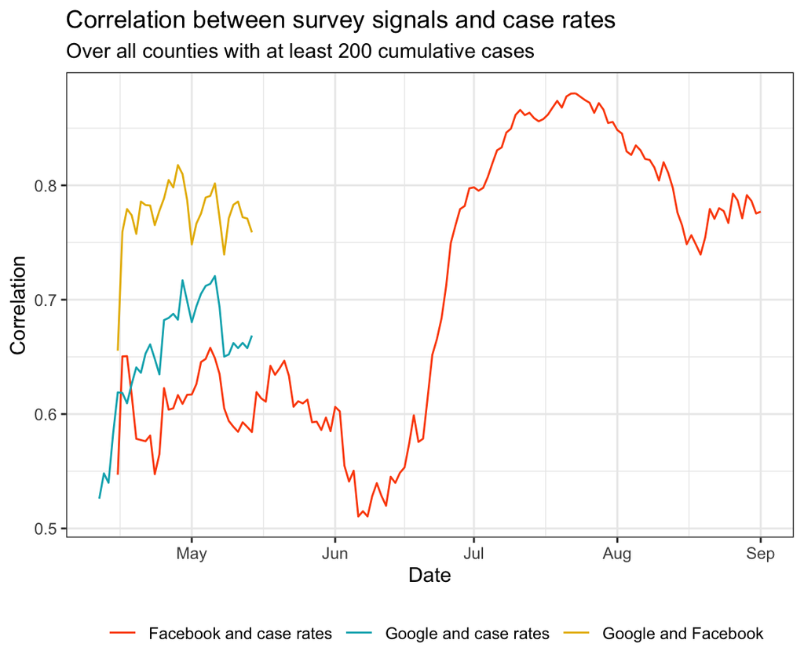

```r
# Fetch county-level Google and Facebook % CLI-in-community signals, and JHU
# confirmed case incidence proportion
start_day = "2020-04-11"
end_day = "2020-09-01"
df_go = covidcast_signal("google-survey", "smoothed_cli")
df_fb = covidcast_signal("fb-survey", "smoothed_hh_cmnty_cli",
                         start_day, end_day)
df_in = covidcast_signal("jhu-csse", "confirmed_7dav_incidence_prop",
                         start_day, end_day)

# Consider only counties with at least 200 cumulative cases by Google's end
case_num = 200
geo_values = covidcast_signal("jhu-csse", "confirmed_cumulative_num",
                              max(df_go$time_value), max(df_go$time_value)) %>%
  filter(value >= case_num) %>% pull(geo_value)
df_go_act = df_go %>% filter(geo_value %in% geo_values)
df_fb_act = df_fb %>% filter(geo_value %in% geo_values)
df_in_act = df_in %>% filter(geo_value %in% geo_values)

# Compute correlations, per time, over all counties
df_cor1 = covidcast_cor(df_go_act, df_in_act, by = "time_value",
                        method = "spearman")
df_cor2 = covidcast_cor(df_fb_act, df_in_act, by = "time_value",
                        method = "spearman")
df_cor3 = covidcast_cor(df_go_act, df_fb_act, by = "time_value",
                        method = "spearman")

# Stack rowwise into one data frame, then plot time series
df_cor = rbind(df_cor1, df_cor2, df_cor3)
df_cor$what = c(rep("Google and case rates", nrow(df_cor1)),
                rep("Facebook and case rates", nrow(df_cor2)),
                rep("Google and Facebook", nrow(df_cor3)))
ggplot(df_cor, aes(x = time_value, y = value)) +
  geom_line(aes(color = what)) +
  scale_color_manual(values = ggplot_colors) +
  labs(title = "Correlation between survey signals and case rates",
       subtitle = sprintf("Over all counties with at least %i cumulative cases",
                          case_num, max(df_go$time_value)),
       x = "Date", y = "Correlation") +
    theme_bw() + theme(legend.pos = "bottom", legend.title = element_blank())
```

Now let’s consider the differences between the surveys. Here’s a summary:

- Our Facebook survey is *advertised by Facebook* but *run by us* (on a CMU-licensed Qualtrics platform); this means that we receive all the individual survey responses directly (and Facebook never sees any of the data).
- On the other hand, our Google survey is *deployed directly by Google* through partner websites and apps they use to run questionnaires; this means that we don’t see individual survey responses, but receive aggregated survey data from Google.
- This makes a big difference as to how much (and what questions) we can ask on the survey: our Google survey is just a single question long, and our Facebook survey is much longer and more detailed, currently over 35 questions. This allows us (and other researchers) to study many more questions about how the pandemic has affected society.
- Finally, there’s a big difference in how much we control with respect to the geographic distribution of the survey samples: on our Facebook survey, we have no control over this, but on our Google survey we have full control, in that we can pick the counties we want to sample from ahead of time.

As we can see, the two survey schemes are complementary, and could be used synergistically. Our Facebook survey is a continuously-running, wide-reaching instrument that provides answers to a [rich set of questions](https://cmu-delphi.github.io/delphi-epidata/symptom-survey/coding.html) (beyond COVID-related symptoms, it asks about contacts, risk factors, behavior, and demographics). When we find something interesting that warrants follow-up and/or generalization to unseen locations, we could then deploy our Google survey in select counties—using it like a **survey microscope** (credit to Hal Varian for inventing the terminology!). This could be done automatically (it would be a pretty big, nonstationary multi-armed bandit problem) or manually (in collaboration with partners in public health and/or data journalists). Stay tuned to the Delphi blog for updates.

## Forecasting Demo

We finish by showing how the % CLI-in-community indicators from our Google and Facebook surveys can be used to improve the accuracy of short-term forecasts of county-level COVID-19 case incidence rates. Forecasting is one of Delphi’s main initiatives (in the past for flu, and currently for COVID-19), and each week since mid-July we’ve been submitting forecasts to the [COVID Forecast Hub](https://covid19forecasthub.org), which serves as the official data source for the [CDC’s communications on COVID-19 forecasts](https://www.cdc.gov/coronavirus/2019-ncov/covid-data/mathematical-modeling.html). To be clear, what follows is meant as a demo, and *not* an authoritative report on cutting-edge forecasting. The purpose is to study whether the Google and Facebook % CLI-in-community signals provide value, when used as features, on top of what we can get from fairly simple time series models that use case rates alone. We’ll follow up in a future blog post with details on our forecasters “in production”.

Next we explain the setup and results in detail; some parts may get a bit technical, but you should be able to glean the main results even if you skip over the details.

### Problem Setup

We consider predicting county-level COVID-19 case incidence rates, 1 and 2 weeks ahead, that is, we consider predicting the number of new COVID-19 cases per capita, over the next 1-7 days and over the next 8-14 days. An equivalent way to phrase this problem (which happens to be more convenient for us) is to predict the *smoothed* COVID-19 case incidence rate 7 days ahead and 14 days ahead, where the smoothing is done via a 7 day trailing average. We restrict our attention to the 440 counties that had at least 200 confirmed cases by May 14, and in which both the Google and Facebook % CLI-in-community signals are available (there were 604 counties in total with at least 200 confirmed cases by May 14, and we dropped 164 of them due to a lack of Google or Facebook survey data).

To fix notation, let $Y_{\ell,t}$ denote the smoothed COVID-19 case incidence rate for location (county) $\ell$ and time (day) $t$. Let $F_{\ell,t}$ and $G_{\ell,t}$ denote the Facebook and Google % CLI-in-community signals, respectively, for location $\ell$ and time $t$. (We rescale all these signals from their given values in our API so that they are true proportions: between 0 and 1.) We evaluate the following four models:
$$\begin{alignat*}{2}
&\text{"Cases"}: \quad && h(Y_{\ell,t+d})
\approx \alpha + \sum_{j=0}^2 \beta_j h(Y_{\ell,t-7j}) \\
&\text{"Cases + Google"}: \quad && h(Y_{\ell,t+d})
\approx \alpha + \sum_{j=0}^2 \beta_j h(Y_{\ell,t-7j}) +
\sum_{j=0}^2 \gamma_j h(G_{\ell,t-7j}) \\
&\text{"Cases + Facebook"}: \quad && h(Y_{\ell,t+d})
\approx \alpha + \sum_{j=0}^2 \beta_j h(Y_{\ell,t-7j}) +
\sum_{j=0}^2 \gamma_j h(F_{\ell,t-7j}) \\
&\text{"Cases + Google + Facebook"}: \quad && h(Y_{\ell,t+d})
\approx \alpha + \sum_{j=0}^2 \beta_j h(Y_{\ell,t-7j}) +
\sum_{j=0}^2 \gamma_j h(G_{\ell,t-7j}) + \sum_{j=0}^2 \tau_j h(F_{\ell,t-7j}).
\end{alignat*}$$
Here $d=7$ or $d=14$, depending on the target value (number of days we predict ahead), and $h$ is a transformation to be specified later. In words, in the first model we’re using current COVID-19 case rates, as well as those 1 and 2 weeks back, in order to predict future case rates; in the second, we’re additionally using the current Google signal, and this signal 1 and 2 weeks back; in the third, it’s the same but with the Facebook signal instead of the Google one; and in the fourth, we use both Google and Facebook signals. For each model, in order to make a forecast at time $t_0$ (to predict case rates for time $t_0+d$), we fit the model using least absolute deviations (LAD) regression, training over all $\ell$ (all 440 counties), and all $t$ that are within the most recent 14 days of data available up to and including time $t_0$.

Forecasts are transformed back to the original scale (we apply $h^{-1}$ to the predictions from the fitted LAD model), and denoted $\hat{Y}_{\ell,t_0+d}$. For an error metric, we consider scaled (absolute) error:
$$\frac{|\hat{Y}_{\ell,t_0+d} - Y_{\ell,t_0+d}|}
{|Y_{\ell,t_0} - Y_{\ell,t_0+d}|},$$
where the error in the denominator is the error of the “strawman” model, which for any target always just predicts the most recent available case rate.

### Transformations

We investigated three transformations $h$: identity, log, and logit (the latter two being common variance-stabilizing transforms for proportions). The results in all three cases were quite similar and the qualitative conclusions don’t change at all (the code below supports all three, so you can check this for yourself). For brevity, we’ll just show the results for the logit transform (actually, a “padded” version $h(x) = \log\big(\frac{x+a}{1-x+a}\big)$, where the numerator and denominator are pushed away from zero by a small constant, which we took to be $a=0.01$).

### Forecasting Code

The code below marches the forecast date $t_0$ forward, one day at a time (from April 11 to September 1) fits the four models, makes 7 and 14 day ahead predictions, and records errors. It actually takes a little while to run, the culprit being LAD regression: here the training sets get moderately large (aggregating the data over 440 counties and 14 days results in over 6000 training samples), and at this scale LAD regression is much slower than (say) least squares regression. We ran this R code separately and saved the results in an RData file; you can find this in the [same GitHub repo as that containing the Rmd source for this blog post](https://github.com/cmu-delphi/delphi-blog/tree/main/content/post).

```r
library(covidcast)
library(dplyr)
library(tidyr)

#### Functions #####

# Function to append shift values (lags or leads) to data frame
append_shifts = function(df, shifts) {
  # Make sure that we have a complete record of dates for each geo_value (fill
  # with NAs as necessary)
  df_all = df %>% group_by(geo_value) %>%
    summarize(time_value = seq.Date(as.Date(min(time_value)),
                                    as.Date(max(time_value)),
                                    by = "day")) %>% ungroup()
  df = full_join(df, df_all, by = c("geo_value", "time_value"))

  # Group by geo value, sort rows by increasing time
  df = df %>% group_by(geo_value) %>% arrange(time_value)

  # Load over shifts, and add lag value or lead value
  for (shift in shifts) {
    fun = ifelse(shift < 0, lag, lead)
    varname = sprintf("value%+d", shift)
    df = mutate(df, !!varname := fun(value, n = abs(shift)))
  }

  # Ungroup and return
  return(ungroup(df))
}

# Some useful functions for transformations
Log = function(x, a = 0.01) log(x + a)
Exp = function(y, a = 0.01) exp(y) - a
Logit = function(x, a = 0.01) log((x + a) / (1 - x + a))
Sigmd = function(y, a = 0.01) (exp(y) * (1 + a) - a) / (1 + exp(y))
Id = function(x) x

# Transforms to consider, in what follows
trans = Logit
inv_trans = Sigmd

# Rescale factors for our signals: bring them all down to proportions (between
# 0 and 1)
rescale_g = 1e-2 # Originally a percentage
rescale_f = 1e-2 # Originally a percentage
rescale_c = 1e-5 # Originally a count per 100,000 people

#### Data #####

# Consider only counties with at least 200 cumulative cases by Google's end
case_num = 200
geo_values = covidcast_signal("jhu-csse", "confirmed_cumulative_num",
                              "2020-05-14", "2020-05-14") %>%
  filter(value >= case_num) %>% pull(geo_value)

# Fetch county-level Google and Facebook % CLI-in-community signals, and JHU
# confirmed case incidence proportion
start_day = "2020-04-11"
end_day = "2020-09-01"
g = covidcast_signal("google-survey", "smoothed_cli") %>%
  select(geo_value, time_value, value) %>%
  filter(geo_value %in% geo_values)
f = covidcast_signal("fb-survey", "smoothed_hh_cmnty_cli",
                     start_day, end_day) %>%
  select(geo_value, time_value, value) %>%
  filter(geo_value %in% geo_values)
c = covidcast_signal("jhu-csse", "confirmed_7dav_incidence_prop",
                     start_day, end_day) %>%
  select(geo_value, time_value, value) %>%
  filter(geo_value %in% geo_values)

# Find "complete" counties, present in all three data signals
geo_values_complete = intersect(intersect(g$geo_value, f$geo_value),
                                c$geo_value)

# Filter to complete counties, transform the signals, append 1-2 week lags to
# all three, and also 1-2 week leads to case rates
lags = -1:-2 * 7
leads = 1:2 * 7
g = g %>% filter(geo_value %in% geo_values_complete) %>%
  mutate(value = trans(value * rescale_g)) %>%
  append_shifts(shifts = lags)
f = f %>% filter(geo_value %in% geo_values_complete) %>%
  mutate(value = trans(value * rescale_f)) %>%
  append_shifts(shifts = lags)
c = c %>% filter(geo_value %in% geo_values_complete) %>%
  mutate(value = trans(value * rescale_c)) %>%
  append_shifts(shifts = c(lags, leads))

# Rename columns
colnames(g) = sub("^value", "goog", colnames(g))
colnames(f) = sub("^value", "fb", colnames(f))
colnames(c) = sub("^value", "case", colnames(c))

# Make one big matrix by joining these three data frames
z = full_join(full_join(g, f, by = c("geo_value", "time_value")),
              c, by = c("geo_value", "time_value"))

##### Analysis #####

# Use quantgen for LAD regression (this package supports quantile regression and
# more; you can find it on GitHub here: https://github.com/ryantibs/quantgen)
library(quantgen)

res_list = vector("list", length = length(leads))
n = 14 # Number of trailing days to use for training set
verbose = TRUE # Print intermediate progress to console?

# Loop over lead, forecast dates, build models and record errors (warning: this
# computation takes a while)
for (i in 1:length(leads)) {
  lead = leads[i]; if (verbose) cat("***", lead, "***\n")

  # Create a data frame to store our results. Code below populates its rows in a
  # way that breaks from typical dplyr operations, done for efficiency
  res_list[[i]] = z %>%
    filter(between(time_value, as.Date(start_day) - min(lags) + lead,
                   as.Date(end_day) - lead)) %>%
    select(geo_value, time_value) %>%
    mutate(err0 = as.double(NA), err1 = as.double(NA), err2 = as.double(NA),
           err3 = as.double(NA), err4 = as.double(NA), lead = lead)
  valid_dates = unique(res_list[[i]]$time_value)

  for (j in 1:length(valid_dates)) {
    date = valid_dates[j]; if (verbose) cat(format(date), "... ")

    # Filter down to training set and test set
    z_tr = z %>% filter(between(time_value, date - lead - n, date - lead))
    z_te = z %>% filter(time_value == date)
    inds = which(res_list[[i]]$time_value == date)

    # Create training and test responses
    y_tr = z_tr %>% pull(paste0("case+", lead))
    y_te = z_te %>% pull(paste0("case+", lead))

    # Strawman model
    if (verbose) cat("0")
    y_hat = z_te %>% pull(case)
    res_list[[i]][inds,]$err0 = abs(inv_trans(y_hat) - inv_trans(y_te))

    # Cases only model
    if (verbose) cat("1")
    x_tr_case = z_tr %>% select(starts_with("case") & !contains("+"))
    x_te_case = z_te %>% select(starts_with("case") & !contains("+"))
    x_tr = x_tr_case; x_te = x_te_case # For symmetry wrt what follows
    ok = complete.cases(x_tr, y_tr)
    if (sum(ok) > 0) {
      obj = quantile_lasso(as.matrix(x_tr[ok,]), y_tr[ok], tau = 0.5,
                           lambda = 0, stand = FALSE, lp_solver = "gurobi")
      y_hat = as.numeric(predict(obj, newx = as.matrix(x_te)))
      res_list[[i]][inds,]$err1 = abs(inv_trans(y_hat) - inv_trans(y_te))
    }

    # Cases and Google model
    if (verbose) cat("2")
    x_tr_goog = z_tr %>% select(starts_with("goog"))
    x_te_goog = z_te %>% select(starts_with("goog"))
    x_tr = cbind(x_tr_case, x_tr_goog)
    x_te = cbind(x_te_case, x_te_goog)
    ok = complete.cases(x_tr, y_tr)
    if (sum(ok) > 0) {
      obj = quantile_lasso(as.matrix(x_tr[ok,]), y_tr[ok], tau = 0.5,
                           lambda = 0, stand = FALSE, lp_solver = "gurobi")
      y_hat = as.numeric(predict(obj, newx = as.matrix(x_te)))
      res_list[[i]][inds,]$err2 = abs(inv_trans(y_hat) - inv_trans(y_te))
    }

    # Cases and Facebook model
    if (verbose) cat("3")
    x_tr_fb = z_tr %>% select(starts_with("fb"))
    x_te_fb = z_te %>% select(starts_with("fb"))
    x_tr = cbind(x_tr_case, x_tr_fb)
    x_te = cbind(x_te_case, x_te_fb)
    ok = complete.cases(x_tr, y_tr)
    if (sum(ok) > 0) {
      obj = quantile_lasso(as.matrix(x_tr[ok,]), y_tr[ok], tau = 0.5,
                           lambda = 0, stand = FALSE, lp_solver = "gurobi")
      y_hat = as.numeric(predict(obj, newx = as.matrix(x_te)))
      res_list[[i]][inds,]$err3 = abs(inv_trans(y_hat) - inv_trans(y_te))
    }

    # Cases, Google, and Facebook model
    if (verbose) cat("4\n")
    x_tr = cbind(x_tr_case, x_tr_goog, x_tr_fb)
    x_te = cbind(x_te_case, x_te_goog, x_te_fb)
    ok = complete.cases(x_tr, y_tr)
    if (sum(ok) > 0) {
      obj = quantile_lasso(as.matrix(x_tr[ok,]), y_tr[ok], tau = 0.5,
                           lambda = 0, stand = FALSE, lp_solver = "gurobi")
      y_hat = as.numeric(predict(obj, newx = as.matrix(x_te)))
      res_list[[i]][inds,]$err4 = abs(inv_trans(y_hat) - inv_trans(y_te))
    }
  }
}

# Bind results over different leads into one big data frame
res = do.call(rbind, res_list)
```

### Caveats

Before diving into the results, we emphasize once more that this is just a demo; our analysis is pretty simple and lacks a few qualities that a truly comphrensive, realistic forecasting analysis should possess. To name three:

1. The models we consider are simple autoregressive structures from standard time series, and could be improved (including, considering other relevant dimensions like mobility measures, county health metrics, etc.).
2. The forecasts we produce are *point* rather than *distributional* forecasts (that is, we predict a single number, rather than an entire distribution, for what happens 7 and 14 days ahead). Distributional forecasts portray uncertainty in a transparent way, which is hugely important in practice.
3. The way we train our forecasts does *not* account for data latency and data revisions, which are critical issues. For each (restrospective) forecast date $t_0$, we construct forecasts by training on data that we fetched from the API today, “as of” the day we wrote this blog post, and not “as of” the forecast date $t_0$. This matters because nearly all signals are subject to latency (they are only available at some number of days lag) and go through multiple revisions (past data values get updated as time goes on).

On the flip side, our example here is not that “far away” from being realistic. First, the models we consider are actually not too different from Delphi’s forecasters “in production”.[^3] Second, the way we’re fitting LAD regression models in the code extends immediately to multiple quantile regression (just requires changing the parameter `tau` in the call to `quantile_lasso()`), which would give us distributional forecasts. And third, it’s fairly easy to change the data acquisition step in the code so that data gets pulled “as of” the forecast date (requires specifying the parameter `as_of` in the call to `covidcast_signal()`).

### Results: All Four Models

We first compare the results across all four models. For this analysis, we filter down to common forecast dates available for the four models (to set an even footing for the comparison), which ends up being May 6 through May 14 for 7 day ahead forecasts, and only May 13 through May 14 for 14 day ahead forecasts. Hence we skip studying the 14 day ahead forecasts results (in this four-way model discussion) as they’re only based on 2 days of test data.

Below we compute and print the median scaled errors for each of the four models over the 9 day test period (recall that the scaled error is the absolute error of the model’s forecast relative to that of the strawman; and each test day actually comprises 440 forecasts, over the 440 counties being considered). We can see that adding either or both of the survey signals improves on the median scaled error of the model that uses cases only, with the biggest gain achieved by the “Cases + Google” model. We can also see that the median scaled errors are all close to 1 (with all but that from “Cases + Google” model exceeding 1), which speaks to the difficulty of the forecasting problem.

```r
load("google-fb-forecast-demo/demo.rda")

# Restrict to common period for all 4 models, then calculate the scaled errors
# for each model, that is, the error relative to the strawman's error
res_all4 = res %>%
  tidyr::drop_na() %>%                                # Restrict to common time
  mutate(err1 = err1 / err0, err2 = err2 / err0,      # Compute relative error
         err3 = err3 / err0, err4 = err4 / err0) %>%  # to strawman model
  mutate(dif12 = err1 - err2, dif13 = err1 - err3,    # Compute differences
         dif14 = err1 - err4) %>%                     # relative to cases model
  ungroup() %>%
  select(-err0)

# Calculate and print median errors, for all 4 models, and just 7 days ahead
res_err4 = res_all4 %>%
  select(-starts_with("dif")) %>%
  tidyr::pivot_longer(names_to = "model", values_to = "err",
                      cols = -c(geo_value, time_value, lead)) %>%
  mutate(lead = factor(lead, labels = paste(leads, "days ahead")),
         model = factor(model,
                        labels = c("Cases", "Cases + Google",
                                   "Cases + Facebook",
                                   "Cases + Google + Facebook")))

knitr::kable(res_err4 %>%
               group_by(model, lead) %>%
               summarize(err = median(err), n = length(unique(time_value))) %>%
               arrange(lead) %>% ungroup() %>%
               rename("Model" = model, "Median scaled error" = err,
                      "Target" = lead, "Test days" = n) %>%
               filter(Target == "7 days ahead"),
             caption = paste("Test period:", min(res_err4$time_value), "to",
                             max(res_err4$time_value)),
             format = "html", table.attr = "style='width:70%;'")
```

Test period: 2020-05-06 to 2020-05-14

| Model | Target | Median scaled error | Test days |
| --- | --- | --- | --- |
| Cases | 7 days ahead | 1.0393350 | 9 |
| Cases + Google | 7 days ahead | 0.9838905 | 9 |
| Cases + Facebook | 7 days ahead | 1.0111709 | 9 |
| Cases + Google + Facebook | 7 days ahead | 1.0166887 | 9 |

Are these differences in median scaled errors significant? It’s hard to say, but some basic statistical inference (testing for equality of medians) suggests that they probably are.[^4]

### Results: “Cases + Facebook”

Next we focus on comparing results between the “Cases” and “Cases + Facebook” models only. Restricting to a common available forecast dates yields a much longer test period, May 6 through August 25 for 7 day ahead forecasts, and May 13 through August 18 for 14 day ahead forecasts. The median scaled errors over the test period are computed and reported below. Now we see a decent improvement in median scaled error for the “Cases + Facebook” model, and this is true for both 7 and 14 day ahead forecasts.

```r
# Restrict to common period for just models 1 and 3, then calculate the scaled
# errors, that is, the error relative to the strawman's error
res_all2 = res %>%
  select(-c(err2, err4)) %>%
  tidyr::drop_na() %>%                                # Restrict to common time
  mutate(err1 = err1 / err0, err3 = err3 / err0) %>%  # Compute relative error
                                                      # to strawman model
  mutate(dif13 = err1 - err3) %>%                     # Compute differences
                                                      # relative to cases model
  ungroup() %>%
  select(-err0)

# Calculate and print median errors, for just models 1 and 3, and both 7 and 14
# days ahead
res_err2 = res_all2 %>%
  select(-starts_with("dif")) %>%
  tidyr::pivot_longer(names_to = "model", values_to = "err",
                      cols = -c(geo_value, time_value, lead)) %>%
  mutate(lead = factor(lead, labels = paste(leads, "days ahead")),
         model = factor(model, labels = c("Cases", "Cases + Facebook")))

knitr::kable(res_err2 %>%
               select(-starts_with("dif")) %>%
               group_by(model, lead) %>%
               summarize(err = median(err), n = length(unique(time_value))) %>%
               arrange(lead) %>% ungroup() %>%
               rename("Model" = model, "Median scaled error" = err,
                      "Target" = lead, "Test days" = n),
             caption = paste("Test period:", min(res_err2$time_value), "to",
                             max(res_err2$time_value)),
             format = "html", table.attr = "style='width:70%;'")
```

Test period: 2020-05-06 to 2020-08-25

| Model | Target | Median scaled error | Test days |
| --- | --- | --- | --- |
| Cases | 7 days ahead | 0.9579148 | 112 |
| Cases + Facebook | 7 days ahead | 0.9396067 | 112 |
| Cases | 14 days ahead | 1.0012286 | 98 |
| Cases + Facebook | 14 days ahead | 0.9752185 | 98 |

Thanks to the extended length of the test period, we can also “unravel” these median scaled errors over time and plot their trajectories, as we do below, with the left plot concerning 7 day ahead forecasts, and the right 14 day ahead forecasts. These plots reveal something quite interesting (and bothersome): the median scaled errors are actually quite volatile over time, and for some periods in July, forecasting became much “harder”, with the scaled errors reaching above 1.25 for 7 day ahead forecasts, and above 1.5 for 14 day ahead forecasts. Furthermore, towards the positive, we can see a clear visual difference between the median scaled errors from the “Cases + Facebook” model in red and the “Cases” model in black. The former appears to be below the latter pretty consistently over time, with the possible exception of periods where forecasting becomes “hard” and the scaled errors shoot above 1. Again, basic statistical inference (testing for equality of medians) suggests that the results we’re seeing here are likely significant, though it’s hard to say definitively given the complicated dependence structure present in the data.[^5]

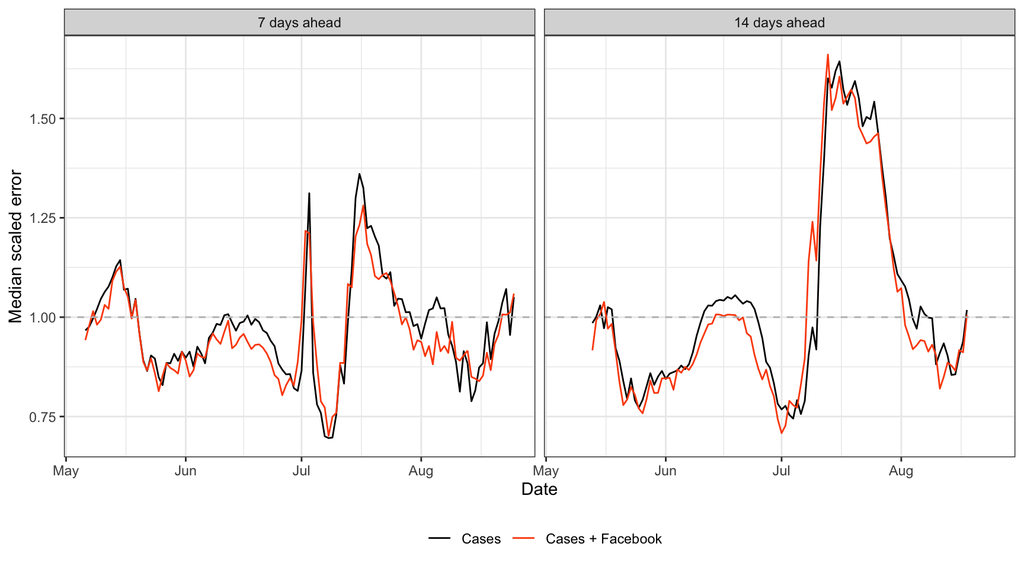

```r
# Plot median errors as a function of time, for models 1 and 3, and both 7 and
# 14 days ahead
ggplot(res_err2 %>%
         group_by(model, lead, time_value) %>%
         summarize(err = median(err)),
       aes(x = time_value, y = err)) +
  geom_line(aes(color = model)) +
  scale_color_manual(values = c("black", ggplot_colors)) +
  geom_hline(yintercept = 1, linetype = 2, color = "gray") +
  facet_wrap(vars(lead)) +
  labs(x = "Date", y = "Median scaled error") +
  theme_bw() + theme(legend.pos = "bottom", legend.title = element_blank())
```

**Acknowledgements.** *Ryan Tibshirani wrote the initial code for producing estimates from the aggregated survey data. Sangwon Hyun, Natalia Lombardi de Oliveira, and Lester Mackey greatly extended and improved this codebase, and they developed, along with Ryan, the underlying statistical methodology. Ryan came up with the idea of running the surveys, and worked with Google to make this a reality. On the Google side, Brett Slatkin and Hal Varian have been key collaborators; Brett wrote the code to get daily survey data over to Delphi’s estimation pipeline; and both contributed numerous important ideas at various stages of the project.*

*[Ryan Tibshirani](http://stat.cmu.edu/~ryantibs) is a lead researcher in the Delphi group, and an Associate Professor in the Department of Statistics & Data Science and the Machine Learning Department at CMU. He is also an Amazon Scholar.*

[^1]: In the survey methodology literature, a “proxy question” is one in which the subject is asked to report on someone else. The traditional view seems to be that proxy questions can undermine survey data quality, but in our setting it’s critical: not only does it provide a safeguard against revealing personal health information, it turned out to deliver [much higher correlations](https://delphi.cmu.edu/blog/2020/08/26/covid-19-symptom-surveys-through-facebook/#basic-correlation-analysis) with case rates than the direct (non-proxy) question.
[^2]: A closer look reveals that the relationship between the Google % CLI-in-community and Facebook % CLI-in-community signals is not 1:1. For example, you can check the x-axes in the first example in this blog post: the range of the Facebook signal is over twice that of the Google signal. There are differences in the setups we can point to: the two surveys phrase the CLI-in-community question slightly differently; they reach different subpopulations of the US; and the estimation procedures behind the surveys handle missing responses differently. But as far as we can tell, none of this can really explain why the Facebook numbers are over twice as large as the Google ones, a trend that seems pretty consistent across location and time. We’ll save rigorous analysis for when we work on deploying these two surveys in tandem; for now, we emphasize that this observation reiterates the importance of focusing on *time-varying trends* in the survey signals, not the signal values themselves (a point we [made in our last post](https://delphi.cmu.edu/blog/2020/08/26/covid-19-symptom-surveys-through-facebook/#why-run-these-surveys)). Here, the self-reporting aspect must somehow be creating greatly different levels of bias in the two surveys; in an absolute sense, the subsequent estimates of % CLI-in-community strongly disagree, so both can’t be right, and this casts doubt on the idea that either could be bias-free.
[^3]: Delphi’s forecasters “in production” are still based on relatively simple times series models, though to be clear they’re distributional, and we add a couple of extra layers of complexity on top of standard structures. For short-term forecasts, we’ve actually found that simple statistical models can be competitive with compartmental models (like SIR and its many variants), even fairly complicated ones. Being statisticians and computer scientists, we find these statistical models are easier to build, debug, and most importantly, calibrate. More on this in a future blog post.
[^4]: For the analysis of the four models, we conduct a sign test below for equality of medians of scaled errors from each model against the “Cases” model. The sign test is run on the 9 test days x 440 counties = 3960 pairs of scaled errors. The p-values for the “Cases” versus “Cases + Google” and the “Cases” versus “Cases + Facebook” comparisons are tiny; the p-value for the “Cases” versus “Cases + Google + Facebook” comparison is much bigger but still significant. However, the sign test here assumes independence of observations, which clearly can’t be true, given the spatiotemporal nature of our problem. To mitigate the dependence across time (which intuitively seems to matter more than that across space), we recomputed these tests in a stratified way, where for each day we run a sign test on the scaled errors between two models over all 440 counties. The results are plotted as histograms below; the “Cases + Google” and “Cases + Facebook” models appear to deliver some decently small p-values, but the story is not as clear with the “Cases + Google + Facebook” model.

    ```r
    # Compute p-values using the sign test against a one-sided alternative, for
    # all models, and just 7 days ahead
    res_dif4 = res_all4 %>%
      select(-starts_with("err")) %>%
      tidyr::pivot_longer(names_to = "model", values_to = "dif",
                          cols = -c(geo_value, time_value, lead)) %>%
      mutate(lead = factor(lead, labels = paste(leads, "days ahead")),
             model = factor(model,
                            labels = c("Cases > Cases + Google",
                                       "Cases > Cases + Facebook",
                                       "Cases > Cases + Google + Facebook")))

    knitr::kable(res_dif4 %>%
                   group_by(model, lead) %>%
                   summarize(p = binom.test(x = sum(dif > 0, na.rm = TRUE),
                                            n = n(), alt = "greater")$p.val) %>%
                   ungroup() %>% filter(lead == "7 days ahead") %>%
                   rename("Comparison" = model, "Target" = lead, "P-value" = p),
                 format = "html", table.attr = "style='width:50%;'")
    ```

    | Comparison | Target | P-value |
    | --- | --- | --- |
    | Cases > Cases + Google | 7 days ahead | 0.0000008 |
    | Cases > Cases + Facebook | 7 days ahead | 0.0000048 |
    | Cases > Cases + Google + Facebook | 7 days ahead | 0.0080695 |

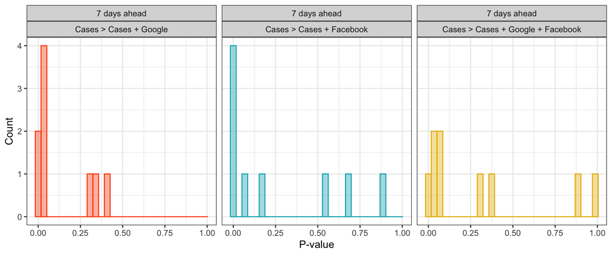

    ```r
    ggplot(res_dif4 %>%
             group_by(model, lead, time_value) %>%
             summarize(p = binom.test(x = sum(dif > 0, na.rm = TRUE),
                                      n = n(), alt = "greater")$p.val) %>%
             ungroup() %>% filter(lead == "7 days ahead"), aes(p)) +
      geom_histogram(aes(color = model, fill = model), alpha = 0.4) +
      scale_color_manual(values = ggplot_colors) +
      scale_fill_manual(values = ggplot_colors) +
      facet_wrap(vars(lead, model)) +
      labs(x = "P-value", y = "Count") +
      theme_bw() + theme(legend.pos = "none")
    ```

[^5]: This is as just as above, but now only comparing “Cases” and “Cases + Facebook”, which gives us many more common test days: 112 for 7 day ahead forecasts and 98 for 14 day ahead forecasts. The p-values below, for the sign test in batch mode, computed over all test days at once, are absolutely tiny; the histograms below, of p-values stratified by forecast date, still show a bulk of small p-values.

    ```r
    # Compute p-values using the sign test against a one-sided alternative, just
    # for models 1 and 3, and both 7 and 14 days ahead
    res_dif2 = res_all2 %>%
      select(-starts_with("err")) %>%
      tidyr::pivot_longer(names_to = "model", values_to = "dif",
                          cols = -c(geo_value, time_value, lead)) %>%
      mutate(lead = factor(lead, labels = paste(leads, "days ahead")),
             model = factor(model, labels = "Cases > Cases + Facebook"))

    knitr::kable(res_dif2 %>%
                   group_by(model, lead) %>%
                   summarize(p = binom.test(x = sum(dif > 0, na.rm = TRUE),
                                            n = n(), alt = "greater")$p.val) %>%
                   ungroup() %>%
                   rename("Comparison" = model, "Target" = lead, "P-value" = p),
                 format = "html", table.attr = "style='width:50%;'")
    ```

    | Comparison | Target | P-value |
    | --- | --- | --- |
    | Cases > Cases + Facebook | 7 days ahead | 0 |
    | Cases > Cases + Facebook | 14 days ahead | 0 |

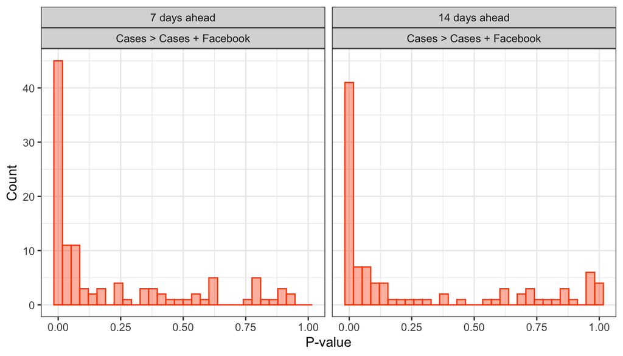

    ```r
    ggplot(res_dif2 %>%
             group_by(model, lead, time_value) %>%
             summarize(p = binom.test(x = sum(dif > 0, na.rm = TRUE),
                                      n = n(), alt = "greater")$p.val) %>%
             ungroup(), aes(p)) +
      geom_histogram(aes(color = model, fill = model), alpha = 0.4) +
      scale_color_manual(values = ggplot_colors) +
      scale_fill_manual(values = ggplot_colors) +
      facet_wrap(vars(lead, model)) +
      labs(x = "P-value", y = "Count") +
      theme_bw() + theme(legend.pos = "none")
    ```